# Voice recognition

Agnese Giacomello

My model is based on the dataset **‘Gender Recognition by Voice’** which consists of 3168 voice samples, half from females and half from males.

The original $.wave$ files have previously been processed in R and are presented as a $.csv$ file with 20 variables, which reflect the frequency parameters of the recorded voices. An extra variable is added ($label$), which corresponds to the sex binary label (male/female).

The goal of my analysis is to build a model that will predict the gender based on the 20 frequency-related variables (binary classification).

These are:

- meanfreq: mean frequency (in kHz)
- sd: standard deviation of frequency
- median: median frequency (in kHz)
- Q25: first quantile (in kHz)
- Q75: third quantile (in kHz)
- IQR: interquantile range (in kHz)
- skew: skewness (see note in specprop description)
- kurt: kurtosis (see note in specprop description)
- sp.ent: spectral entropy
- sfm: spectral flatness
- mode: mode frequency
- centroid: frequency centroid (see specprop)
- peakf: peak frequency (frequency with highest energy)
- meanfun: average of fundamental frequency measured across acoustic signal
- minfun: minimum fundamental frequency measured across acoustic signal
- maxfun: maximum fundamental frequency measured across acoustic signal
- meandom: average of dominant frequency measured across acoustic signal
- mindom: minimum of dominant frequency measured across acoustic signal
- maxdom: maximum of dominant frequency measured across acoustic signal
- dfrange: range of dominant frequency measured across acoustic signal
- modindx: modulation index. Calculated as the accumulated absolute difference between adjacent measurements of fundamental frequencies divided by the frequency range

```r
voices <- read.csv("voice.csv")

# Checking structure of the dataset
str(voices)
```

```
## 'data.frame':    3168 obs. of  21 variables:
##  $ meanfreq: num  0.0598 0.066 0.0773 0.1512 0.1351 ...
##  $ sd      : num  0.0642 0.0673 0.0838 0.0721 0.0791 ...
##  $ median  : num  0.032 0.0402 0.0367 0.158 0.1247 ...
##  $ Q25     : num  0.0151 0.0194 0.0087 0.0966 0.0787 ...
##  $ Q75     : num  0.0902 0.0927 0.1319 0.208 0.206 ...
##  $ IQR     : num  0.0751 0.0733 0.1232 0.1114 0.1273 ...
##  $ skew    : num  12.86 22.42 30.76 1.23 1.1 ...
##  $ kurt    : num  274.4 634.61 1024.93 4.18 4.33 ...
##  $ sp.ent  : num  0.893 0.892 0.846 0.963 0.972 ...
##  $ sfm     : num  0.492 0.514 0.479 0.727 0.784 ...
##  $ mode    : num  0 0 0 0.0839 0.1043 ...
##  $ centroid: num  0.0598 0.066 0.0773 0.1512 0.1351 ...
##  $ meanfun : num  0.0843 0.1079 0.0987 0.089 0.1064 ...
##  $ minfun  : num  0.0157 0.0158 0.0157 0.0178 0.0169 ...
##  $ maxfun  : num  0.276 0.25 0.271 0.25 0.267 ...
##  $ meandom : num  0.00781 0.00901 0.00799 0.2015 0.71281 ...
##  $ mindom  : num  0.00781 0.00781 0.00781 0.00781 0.00781 ...
##  $ maxdom  : num  0.00781 0.05469 0.01562 0.5625 5.48438 ...
##  $ dfrange : num  0 0.04688 0.00781 0.55469 5.47656 ...
##  $ modindx : num  0 0.0526 0.0465 0.2471 0.2083 ...
##  $ label   : Factor w/ 2 levels "female","male": 2 2 2 2 2 2 2 2 2 2 ...
```

```r
knit_print.table <- lemon_print    # Tool for prettier dataframe printing
summary(voices)
```

| meanfreq | sd | median | Q25 | Q75 | IQR | skew | kurt | sp.ent | sfm | mode | centroid | meanfun | minfun | maxfun | meandom | mindom | maxdom | dfrange | modindx | label |
| --- | --- | --- | --- | --- | --- | --- | --- | --- | --- | --- | --- | --- | --- | --- | --- | --- | --- | --- | --- | --- |
| Min. :0.03936 | Min. :0.01836 | Min. :0.01097 | Min. :0.0002288 | Min. :0.04295 | Min. :0.01456 | Min. : 0.1417 | Min. : 2.068 | Min. :0.7387 | Min. :0.03688 | Min. :0.0000 | Min. :0.03936 | Min. :0.05557 | Min. :0.009775 | Min. :0.1031 | Min. :0.007812 | Min. :0.004883 | Min. : 0.007812 | Min. : 0.000 | Min. :0.00000 | female:1584 |
| 1st Qu.:0.16366 | 1st Qu.:0.04195 | 1st Qu.:0.16959 | 1st Qu.:0.1110865 | 1st Qu.:0.20875 | 1st Qu.:0.04256 | 1st Qu.: 1.6496 | 1st Qu.: 5.670 | 1st Qu.:0.8618 | 1st Qu.:0.25804 | 1st Qu.:0.1180 | 1st Qu.:0.16366 | 1st Qu.:0.11700 | 1st Qu.:0.018223 | 1st Qu.:0.2540 | 1st Qu.:0.419828 | 1st Qu.:0.007812 | 1st Qu.: 2.070312 | 1st Qu.: 2.045 | 1st Qu.:0.09977 | male :1584 |
| Median :0.18484 | Median :0.05916 | Median :0.19003 | Median :0.1402864 | Median :0.22568 | Median :0.09428 | Median : 2.1971 | Median : 8.319 | Median :0.9018 | Median :0.39634 | Median :0.1866 | Median :0.18484 | Median :0.14052 | Median :0.046110 | Median :0.2712 | Median :0.765795 | Median :0.023438 | Median : 4.992188 | Median : 4.945 | Median :0.13936 |  |
| Mean :0.18091 | Mean :0.05713 | Mean :0.18562 | Mean :0.1404556 | Mean :0.22476 | Mean :0.08431 | Mean : 3.1402 | Mean : 36.569 | Mean :0.8951 | Mean :0.40822 | Mean :0.1653 | Mean :0.18091 | Mean :0.14281 | Mean :0.036802 | Mean :0.2588 | Mean :0.829211 | Mean :0.052647 | Mean : 5.047277 | Mean : 4.995 | Mean :0.17375 |  |
| 3rd Qu.:0.19915 | 3rd Qu.:0.06702 | 3rd Qu.:0.21062 | 3rd Qu.:0.1759388 | 3rd Qu.:0.24366 | 3rd Qu.:0.11418 | 3rd Qu.: 2.9317 | 3rd Qu.: 13.649 | 3rd Qu.:0.9287 | 3rd Qu.:0.53368 | 3rd Qu.:0.2211 | 3rd Qu.:0.19915 | 3rd Qu.:0.16958 | 3rd Qu.:0.047904 | 3rd Qu.:0.2775 | 3rd Qu.:1.177166 | 3rd Qu.:0.070312 | 3rd Qu.: 7.007812 | 3rd Qu.: 6.992 | 3rd Qu.:0.20918 |  |
| Max. :0.25112 | Max. :0.11527 | Max. :0.26122 | Max. :0.2473469 | Max. :0.27347 | Max. :0.25223 | Max. :34.7255 | Max. :1309.613 | Max. :0.9820 | Max. :0.84294 | Max. :0.2800 | Max. :0.25112 | Max. :0.23764 | Max. :0.204082 | Max. :0.2791 | Max. :2.957682 | Max. :0.458984 | Max. :21.867188 | Max. :21.844 | Max. :0.93237 |  |

```r
sapply(voices, FUN = function(col) sum(is.na(col))) # Double checking presence of missing values
```

```
## meanfreq       sd   median      Q25      Q75      IQR     skew     kurt
##        0        0        0        0        0        0        0        0
##   sp.ent      sfm     mode centroid  meanfun   minfun   maxfun  meandom
##        0        0        0        0        0        0        0        0
##   mindom   maxdom  dfrange  modindx    label
##        0        0        0        0        0
```

### Some data screening

I first performed some data screening: I plotted boxplots and density distributions for each of the 20 variables to investigate whether their distribution was different between males and females. Also, a plot with the Pearson correlations is reported to check possible presence of multicollinearity among the variabels.

```r
# Reshape the data in long format to ease plotting
voices_long <- voices %>%
    gather('feature', 'value', -label)

head(voices_long)
```

```
##   label  feature      value
## 1  male meanfreq 0.05978098
## 2  male meanfreq 0.06600874
## 3  male meanfreq 0.07731550
## 4  male meanfreq 0.15122809
## 5  male meanfreq 0.13512039
## 6  male meanfreq 0.13278641
```

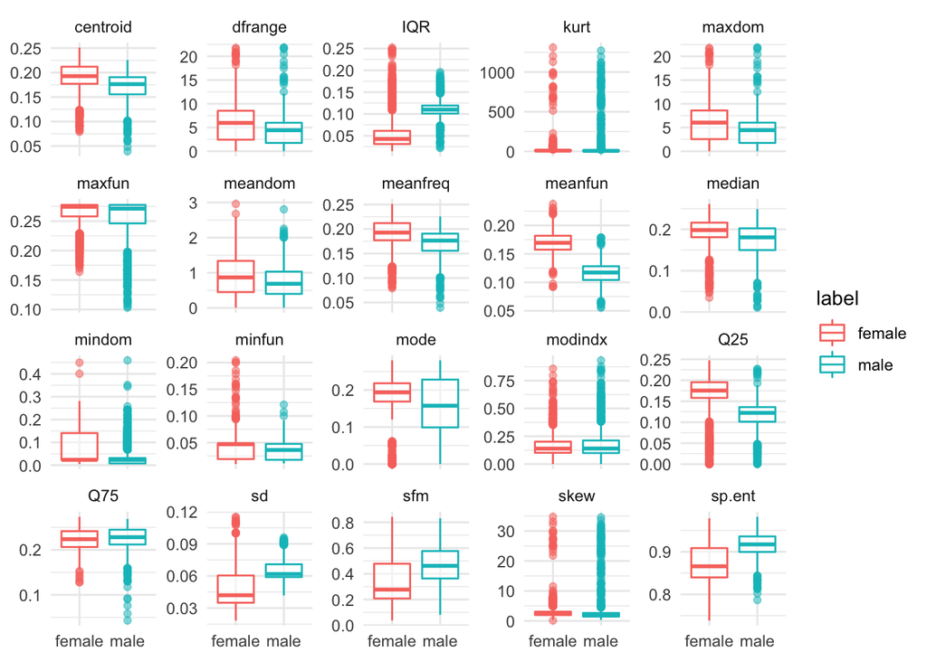

```r
voices_long %>%
    ggplot(aes(label, value, colour = label)) +
        geom_boxplot(alpha = 0.5) +
        facet_wrap(~ feature, scales='free_y', nrow=4) +
        labs(x = NULL, y = NULL) +
        theme_minimal()
```

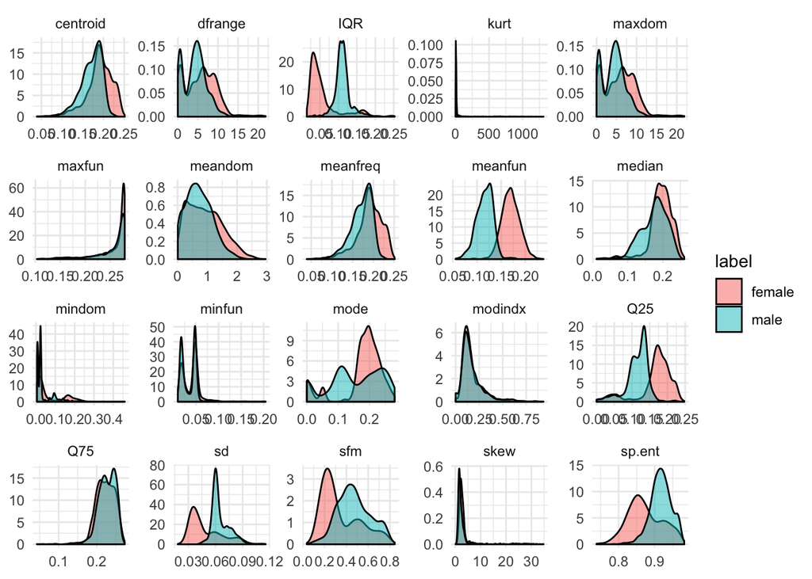

```r
voices_long %>%
    ggplot(aes(value, fill = label)) +
        geom_density(alpha = 0.5) +
        facet_wrap(~ feature, scales='free', nrow=4) +
        labs(x = NULL, y = NULL) +
        theme_minimal()
```

The variables **meanfun, IQR, Q25, sd, mode, sfm** and **sp.ent** appear to have very different distributions among male and females, therefore I would expect them to be relevant variables in the classification model.

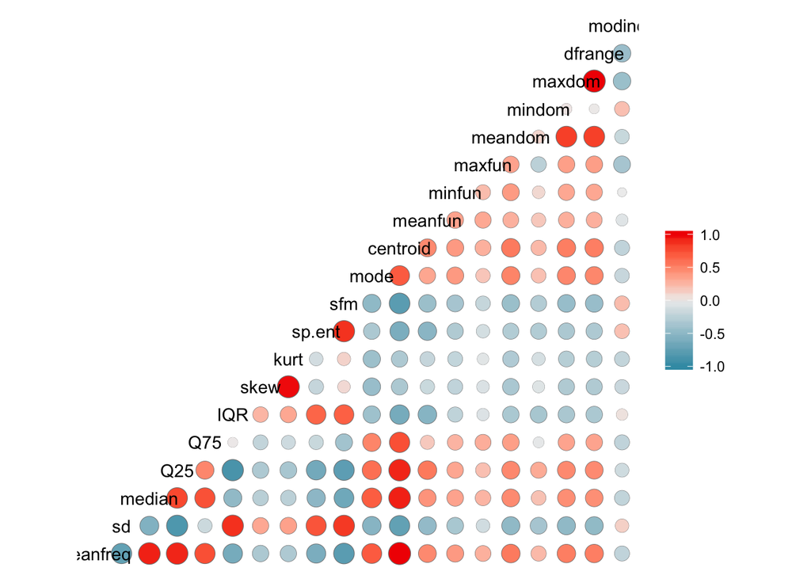

```r
voices %>%
  select_if(is.numeric) %>%
  ggcorr(geom="circle")
```

Some very high correlations are present (e.g. among *spectral entropy* and *spectral flatness*, *frequency centroid* and *mean frequency*, etc.).

Even though they represent different characteristics of the human voice, they refer to the same feature: their values are therefore linearly related, which causes high correlations to be present. This might cause multicollinearity problems when performing logistic regression.

### Predictions

To build a classsification model that predicts gender, I first performed a **classic logistic regression** and then a **random forest** algorithm.

```r
# Train / Test split 70%-30%
set.seed(1231)
idx <- seq(nrow(voices))
idx_train <- sample(idx, size = floor(nrow(voices) * 0.7), replace = FALSE)
idx_test <- idx[!idx %in% idx_train]

train_data  <- voices[idx_train,]
test_data <- voices[idx_test,]

dim(train_data) # Checking correct division
```

```
## [1] 2217   21
```

```r
dim(test_data)
```

```
## [1] 951  21
```

```r
train_data <- train_data %>%
  dplyr::mutate(sex = factor(ifelse(label == 'male', 1, 0))) %>% # Creating a dichotomous variable 0/1 to ease comprison after the model fitting
  select(-label)

test_data <- test_data %>%
  dplyr::mutate(sex = factor(ifelse(label == 'male', 1, 0))) %>% # Creating a dichotomous variable 0/1 to ease comprison after the model fitting
  select(-label)
```

#### Logistic regression

```r
logistic_regression_model <- glm(sex ~ ., data = train_data, family = binomial)
summary(logistic_regression_model)
```

```
##
## Call:
## glm(formula = sex ~ ., family = binomial, data = train_data)
##
## Deviance Residuals:
##     Min       1Q   Median       3Q      Max
## -3.1980  -0.0372  -0.0004   0.1075   4.3073
##
## Coefficients: (3 not defined because of singularities)
##               Estimate Std. Error z value Pr(>|z|)
## (Intercept) -1.312e+01  1.121e+01  -1.170 0.242010
## meanfreq    -1.367e+01  5.604e+01  -0.244 0.807243
## sd           1.642e+01  4.163e+01   0.395 0.693198
## median      -2.263e+00  1.516e+01  -0.149 0.881308
## Q25         -5.438e+01  1.460e+01  -3.725 0.000196 ***
## Q75          6.200e+01  2.418e+01   2.564 0.010339 *
## IQR                 NA         NA      NA       NA
## skew         8.698e-02  2.338e-01   0.372 0.709890
## kurt        -6.135e-03  6.860e-03  -0.894 0.371137
## sp.ent       3.850e+01  1.182e+01   3.257 0.001127 **
## sfm         -1.132e+01  2.999e+00  -3.773 0.000162 ***
## mode         2.665e+00  2.825e+00   0.943 0.345472
## centroid            NA         NA      NA       NA
## meanfun     -1.668e+02  1.049e+01 -15.896  < 2e-16 ***
## minfun       3.347e+01  1.154e+01   2.901 0.003719 **
## maxfun       1.737e+00  7.732e+00   0.225 0.822214
## meandom     -2.296e-01  5.365e-01  -0.428 0.668739
## mindom       2.504e+00  2.499e+00   1.002 0.316480
## maxdom       4.442e-02  7.996e-02   0.556 0.578510
## dfrange             NA         NA      NA       NA
## modindx     -3.482e+00  1.916e+00  -1.817 0.069170 .
## ---
## Signif. codes:  0 '***' 0.001 '**' 0.01 '*' 0.05 '.' 0.1 ' ' 1
##
## (Dispersion parameter for binomial family taken to be 1)
##
##     Null deviance: 3073.31  on 2216  degrees of freedom
## Residual deviance:  390.28  on 2199  degrees of freedom
## AIC: 426.28
##
## Number of Fisher Scoring iterations: 8
```

```r
# Adds a column with predictions and SE to the dataset
augment(logistic_regression_model, newdata = test_data, type.predict = "response") %>%
    head()
```

```
## # A tibble: 6 x 23
##   meanfreq     sd median    Q25   Q75   IQR  skew  kurt sp.ent   sfm   mode
##      <dbl>  <dbl>  <dbl>  <dbl> <dbl> <dbl> <dbl> <dbl>  <dbl> <dbl>  <dbl>
## 1    0.151 0.0721  0.158 0.0966 0.208 0.111 1.23   4.18  0.963 0.727 0.0839
## 2    0.142 0.0780  0.139 0.0882 0.209 0.120 1.10   4.07  0.971 0.771 0.219
## 3    0.157 0.0719  0.168 0.101  0.217 0.115 0.979  3.97  0.965 0.734 0.0964
## 4    0.191 0.0658  0.208 0.132  0.244 0.112 1.56   7.83  0.939 0.539 0.0501
## 5    0.169 0.0718  0.143 0.126  0.248 0.123 3.08  14.3   0.902 0.478 0.128
## 6    0.172 0.0715  0.146 0.133  0.252 0.120 4.50  31.1   0.878 0.470 0.136
## # ... with 12 more variables: centroid <dbl>, meanfun <dbl>, minfun <dbl>,
## #   maxfun <dbl>, meandom <dbl>, mindom <dbl>, maxdom <dbl>,
## #   dfrange <dbl>, modindx <dbl>, sex <fct>, .fitted <dbl>, .se.fit <dbl>
```

```r
# Confusion matrix
augment(logistic_regression_model, type.predict = "response") %>%
    mutate(predictions_logistic = round(.fitted)) %>% # Rounding so to have 0/1 predictions
    select(sex, predictions_logistic) %>%
    table()
```

```
##    predictions_logistic
## sex    0    1
##   0 1084   32
##   1   25 1076
```

```r
accuracy_logistic_regression <- (1084+1076)/(1084+1076+25+32)
accuracy_logistic_regression
```

```
## [1] 0.9742896
```

The logistic regression model showed Q25, sfm, meanfun, minfun, sp.ent and Q75 as significant variables, at a significance level of $\alpha=0.05$.

In particular, coefficients can be interpreted as follows:

- holding all other variables constant, the odds of the voice being male are exp(-54.38) = 2.415828e-24 times higher with a one unit increase in Q25 (the first quantile, in kHz).
- holding all other variables constant, the odds of the voice being male are exp(6.200e+01) = 8.438357e+26 times higher with a one unit increase in Q75 (the third quantile, in kHz).
- holding all other variables constant, the odds of the voice being male are exp(-1.132e+01) = 1.212792e-05 times higher with a one unit increase in spectral flatness.
- holding all other variables constant, the odds of the voice being male are exp(-1.668e+02) = 3.62811e-73 times higher with a one unit increase in meanfun.
- holding all other variables constant, the odds of the voice being male are exp(3.347e+01) = 3.434285e+14 times higher with a one unit increase in minfun.
- holding all other variables constant, the odds of the voice being male are exp(6.200e+01) = 8.438357e+26 times higher with a one unit increase in Q75.

As was anticipated in the data screening, the high correlations found in variables that express different characteristics of the same features caused logistic regression to detect singularities (= linear relations among variabels). When detecting perfectly linear relations among two variables, R automatically includes only one of the two in the analysis.

I’ll compare its performance to a random forest algorithm on the same variables.

### Random forest

```r
set.seed(7)
random_forest <- randomForest(factor(train_data$sex) ~ ., data = train_data, ntree= 300)

random_forest
```

```
##
## Call:
##  randomForest(formula = factor(train_data$sex) ~ ., data = train_data,      ntree = 300)
##                Type of random forest: classification
##                      Number of trees: 300
## No. of variables tried at each split: 4
##
##         OOB estimate of  error rate: 1.71%
## Confusion matrix:
##      0    1 class.error
## 0 1102   14  0.01254480
## 1   24 1077  0.02179837
```

```r
# vector of predictions on the test data (0/1)
set.seed(21)
prediction_randomforest <- predict(random_forest, test_data)
```

```r
# Confusion matrix
table(test_data$sex, prediction_randomforest)
```

```
##    prediction_randomforest
##       0   1
##   0 453  15
##   1   9 474
```

```r
accuracy_randomforest <- (453+474)/(455+474+9+15)
accuracy_randomforest
```

```
## [1] 0.9727177
```

```r
# Checking error distribution along trees for the two classes
OOB = as.data.table(plot(random_forest)) # OOB: out-of-bag
```

```r
OOB[, trees := .I]
```

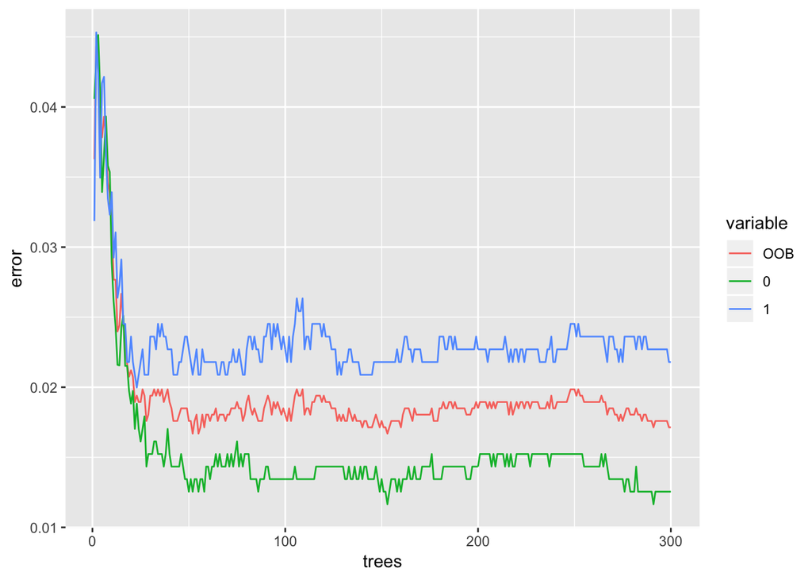

```r
# Transform to long format to ease plotting
OOB_long = melt(OOB, id.vars = "trees")
setnames(OOB_long, "value", "error")

ggplot(data = OOB_long, aes(x = trees, y = error, color = variable)) + geom_line()
```

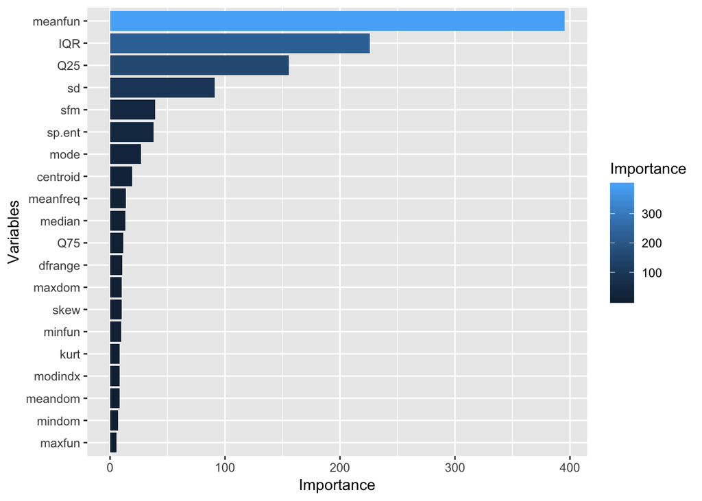

```r
importance    <- importance(random_forest)
importance_dataframe <- data.frame(Variables = row.names(importance),
                            Importance = round(importance[ ,'MeanDecreaseGini'],2))

# Rank variable
importance_rank <- importance_dataframe %>%
  mutate(Rank = paste0('#',dense_rank(desc(importance))))

# Visualisation of the importance of variables
ggplot(importance_rank, aes(x = reorder(Variables, Importance),
    y = Importance, fill = Importance)) +
  geom_bar(stat='identity') +
  labs(x = 'Variables') +
  coord_flip()
```